# ProjectAnalysis

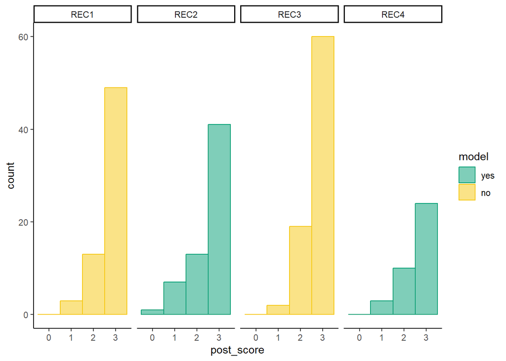

```r
ggplot(sum_s3, aes(x=post_score ))+
  geom_histogram(binwidth=1, aes(color=model, fill = model), alpha = 0.5, position = "identity")+
  facet_grid(. ~ Sctn_Code)+
  scale_fill_manual(values = c("#009E73", "#F5C710"))+
  scale_color_manual(values = c("#009E73", "#F5C710"))+
  theme_classic()
```

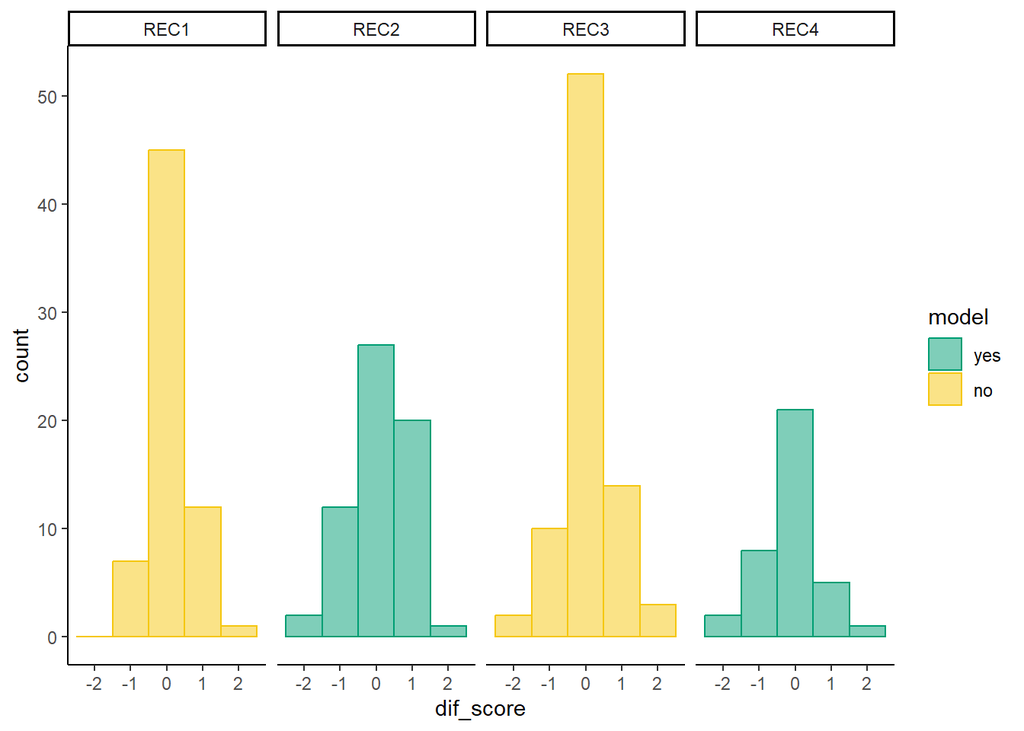

```r
ggplot(sum_s3, aes(x=dif_score ))+
  geom_histogram(binwidth=1, aes(color=model, fill = model), alpha = 0.5, position = "identity")+
  facet_grid(. ~ Sctn_Code)+
  scale_fill_manual(values = c("#009E73", "#F5C710"))+
  scale_color_manual(values = c("#009E73", "#F5C710"))+
  theme_classic()
```

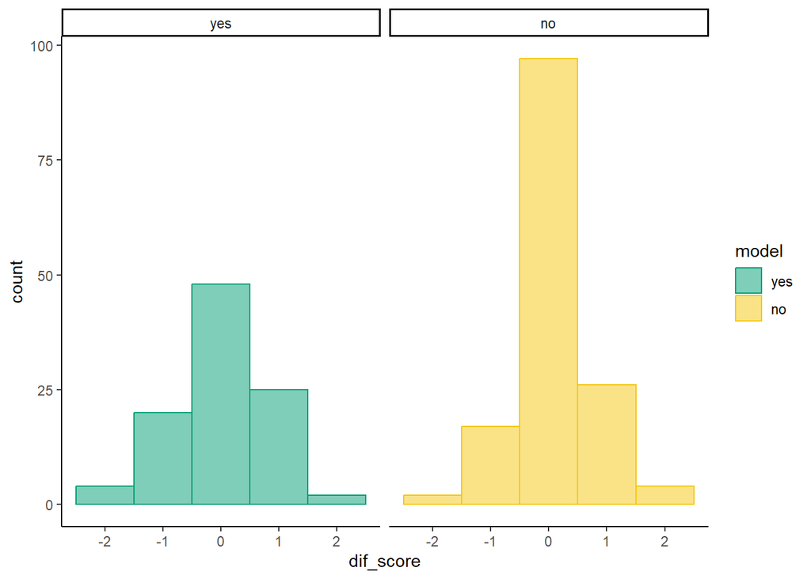

```r
ggplot(sum_s3, aes(x=dif_score ))+
  geom_histogram(binwidth=1, aes(color=model, fill = model), alpha = 0.5, position = "identity")+
  facet_grid(. ~ model)+
  scale_fill_manual(values = c("#009E73", "#F5C710"))+
  scale_color_manual(values = c("#009E73", "#F5C710"))+
  theme_classic()
```

Skill 4 - Understand elements of research design and how they impact scientific findings/conclusions: 5, 14, 15, 26

```r
# keep only the questions I need and only the checked row for each students b/c that will have the score column so I don't need to score by hand.
pre_s4 <- pre_all[pre_all$`Q..` %in% c(5, 14, 15, 26) & pre_all$`Answer.Match` == "Checked", ]

# now group by random number and calculate the score for skill 4
sum_pre_s4 <- pre_s4 %>%
  group_by(Random_Number) %>%
  summarize(pre_score = sum(Score), Sctn_Code = unique(Sctn_Code), model = unique(model))
# add percentage column
sum_pre_s4$pre_perc <- sum_pre_s4$pre_score / 4

# now for post
post_s4 <- post_all[post_all$`Q..` %in% c(5, 14, 15, 26) & post_all$`Answer.Match` == "Checked", ]

# now group by random number and calculate the score for skill 4
sum_post_s4 <- post_s4 %>%
  group_by(Random_Number) %>%
  summarize(post_score = sum(Score), Sctn_Code = unique(Sctn_Code), model = unique(model))
# add percentage column
sum_post_s4$post_perc <- sum_post_s4$post_score / 4

# merge those together
sum_s4 <- merge(sum_pre_s4, sum_post_s4, by = c("Random_Number", "Sctn_Code", "model"))

# calculate the difference in points
sum_s4$dif_score <- sum_s4$post_score - sum_s4$pre_score

# quick check of what things look like by modelling and section
sum_s4 %>%
  group_by(Sctn_Code) %>%
  summarize(mean_pre = mean(pre_perc),
            mean_post = mean(post_perc),
            mean_dif = mean(dif_score))
```

```
## # A tibble: 4 × 4
##   Sctn_Code mean_pre mean_post mean_dif
##   <chr>        <dbl>     <dbl>    <dbl>
## 1 REC1         0.696     0.704   0.0308
## 2 REC2         0.669     0.730   0.242
## 3 REC3         0.651     0.682   0.123
## 4 REC4         0.655     0.703   0.189
```

```r
# 1 highest pre, 2 biggest increase, then 4
# by modelling
sum_s4 %>%
  group_by(model) %>%
  summarize(mean_pre = mean(pre_perc),
            mean_post = mean(post_perc),
            mean_dif = mean(dif_score))
```

```
## # A tibble: 2 × 4
##   model mean_pre mean_post mean_dif
##   <chr>    <dbl>     <dbl>    <dbl>
## 1 no       0.671     0.692   0.0822
## 2 yes      0.664     0.720   0.222
```

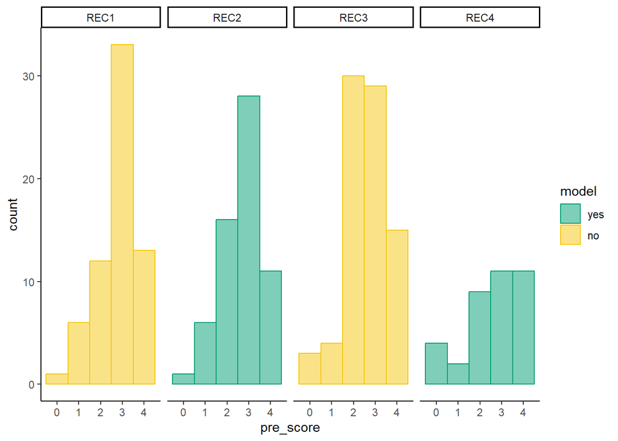

```r
# much bigger increase!

# do t test to see if difference in scores pre/post matters by modelling
dif_s4 <- t.test(dif_score~model, data = sum_s4)

# add skill column
sum_s4$skill <- 4

#plots
sum_s4$model <- factor(sum_s4$model, levels = c("yes", "no"))

ggplot(sum_s4, aes(x=pre_score ))+
  geom_histogram(binwidth=1, aes(color=model, fill = model), alpha = 0.5, position = "identity")+
  facet_grid(. ~ Sctn_Code)+
  scale_fill_manual(values = c("#009E73", "#F5C710"))+
  scale_color_manual(values = c("#009E73", "#F5C710"))+
  theme_classic()
```

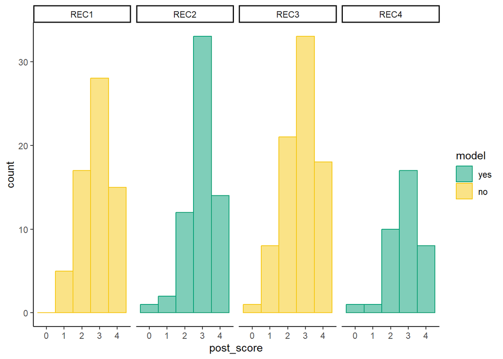

```r
ggplot(sum_s4, aes(x=post_score ))+
  geom_histogram(binwidth=1, aes(color=model, fill = model), alpha = 0.5, position = "identity")+
  facet_grid(. ~ Sctn_Code)+
  scale_fill_manual(values = c("#009E73", "#F5C710"))+
  scale_color_manual(values = c("#009E73", "#F5C710"))+
  theme_classic()
```

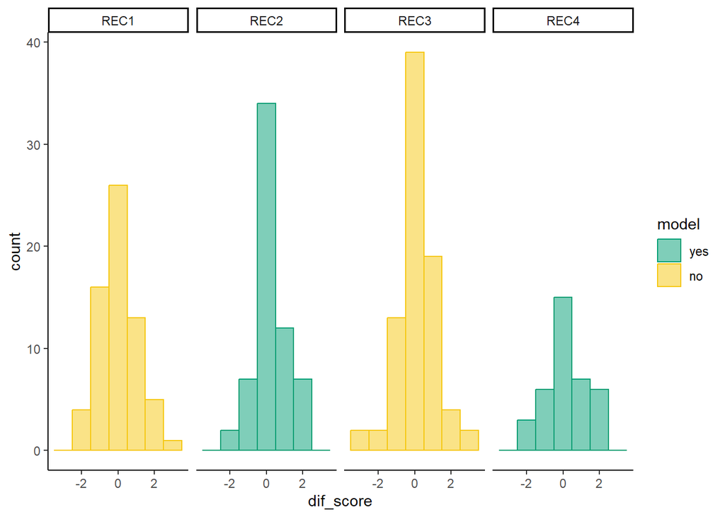

```r
ggplot(sum_s4, aes(x=dif_score ))+
  geom_histogram(binwidth=1, aes(color=model, fill = model), alpha = 0.5, position = "identity")+
  facet_grid(. ~ Sctn_Code)+
  scale_fill_manual(values = c("#009E73", "#F5C710"))+
  scale_color_manual(values = c("#009E73", "#F5C710"))+
  theme_classic()
```

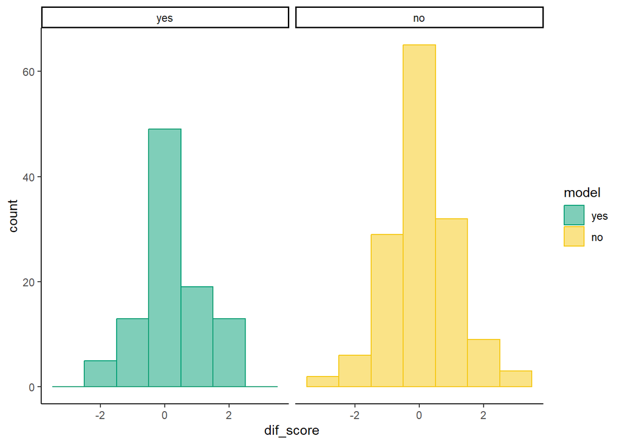

```r
ggplot(sum_s4, aes(x=dif_score ))+
  geom_histogram(binwidth=1, aes(color=model, fill = model), alpha = 0.5, position = "identity")+
  facet_grid(. ~ model)+
  scale_fill_manual(values = c("#009E73", "#F5C710"))+
  scale_color_manual(values = c("#009E73", "#F5C710"))+
  theme_classic()
```

Skill 5 - Make a graph: 16

```r
# keep only the questions I need and only the checked row for each students b/c that will have the score column so I don't need to score by hand.
pre_s5 <- pre_all[pre_all$`Q..` %in% c(16) & pre_all$`Answer.Match` == "Checked", ]

# only 1 q so no need to summarize, but only keep some variables. extra columns for binding later.
pre_s5 <- pre_s5[ , c("Random_Number", "Sctn_Code", "model", "Score")]
# rename columns
colnames(pre_s5) <- c("Random_Number", "Sctn_Code", "model", "pre_score")
# add percentage column
pre_s5$pre_perc <- pre_s5$pre_score / 1

# now for post
post_s5 <- post_all[post_all$`Q..` %in% c(16) & post_all$`Answer.Match` == "Checked", ]
post_s5 <- post_s5[ , c("Random_Number", "Sctn_Code", "model", "Score")]
# rename columns
colnames(post_s5) <- c("Random_Number", "Sctn_Code", "model", "post_score")
# add percentage column
post_s5$post_perc <- post_s5$post_score / 1

# merge those together
sum_s5 <- merge(pre_s5, post_s5, by = c("Random_Number", "Sctn_Code", "model"))

# calculate the difference in points
sum_s5$dif_score <- sum_s5$post_score - sum_s5$pre_score

# quick check of what things look like by modelling and section
sum_s5 %>%
  group_by(Sctn_Code) %>%
  summarize(mean_pre = mean(pre_score),
            mean_post = mean(post_score),
            mean_dif = mean(dif_score))
```

```
## # A tibble: 4 × 4
##   Sctn_Code mean_pre mean_post mean_dif
##   <chr>        <dbl>     <dbl>    <dbl>
## 1 REC1         0.554     0.523  -0.0308
## 2 REC2         0.419     0.532   0.113
## 3 REC3         0.506     0.432  -0.0741
## 4 REC4         0.541     0.405  -0.135
```

```r
# all but section 2 mostly lost this skill.
# by modelling
sum_s5 %>%
  group_by(model) %>%
  summarize(mean_pre = mean(pre_score),
            mean_post = mean(post_score),
            mean_dif = mean(dif_score))
```

```
## # A tibble: 2 × 4
##   model mean_pre mean_post mean_dif
##   <chr>    <dbl>     <dbl>    <dbl>
## 1 no       0.527     0.473  -0.0548
## 2 yes      0.465     0.485   0.0202
```

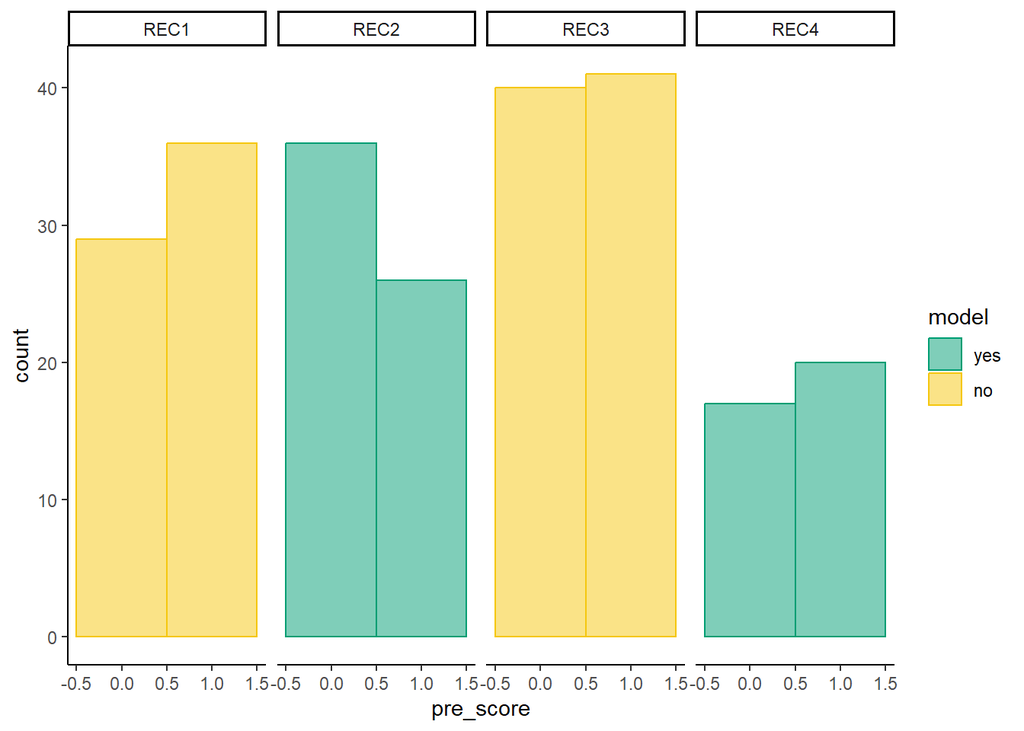

```r
# barely increase but is positive while no is barely negative

# do t test to see if difference in scores pre/post matters by modelling
dif_s5 <- t.test(dif_score~model, data = sum_s5)

# add skill column
sum_s5$skill <- 5

#plots
sum_s5$model <- factor(sum_s5$model, levels = c("yes", "no"))

ggplot(sum_s5, aes(x=pre_score ))+
  geom_histogram(binwidth=1, aes(color=model, fill = model), alpha = 0.5, position = "identity")+
  facet_grid(. ~ Sctn_Code)+
  scale_fill_manual(values = c("#009E73", "#F5C710"))+
  scale_color_manual(values = c("#009E73", "#F5C710"))+
  theme_classic()
```

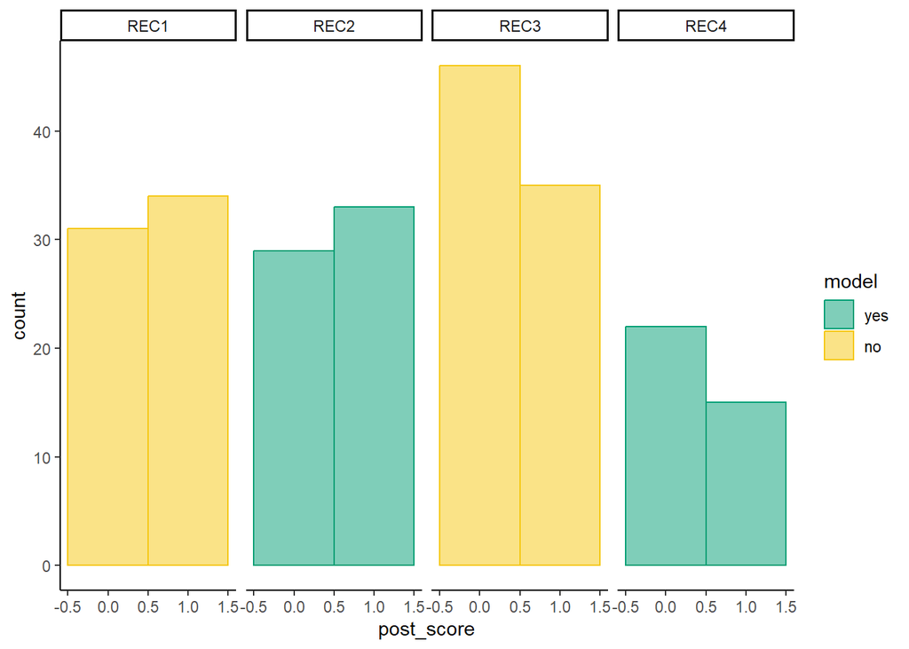

```r
ggplot(sum_s5, aes(x=post_score ))+
  geom_histogram(binwidth=1, aes(color=model, fill = model), alpha = 0.5, position = "identity")+
  facet_grid(. ~ Sctn_Code)+
  scale_fill_manual(values = c("#009E73", "#F5C710"))+
  scale_color_manual(values = c("#009E73", "#F5C710"))+
  theme_classic()
```

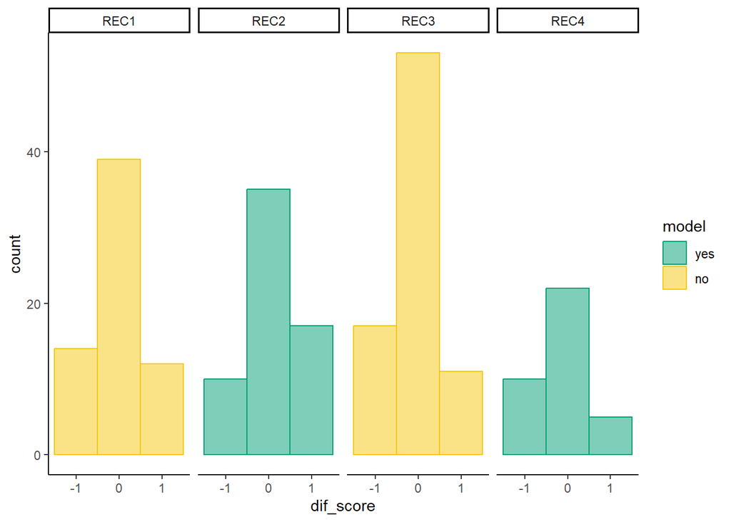

```r
ggplot(sum_s5, aes(x=dif_score ))+
  geom_histogram(binwidth=1, aes(color=model, fill = model), alpha = 0.5, position = "identity")+
  facet_grid(. ~ Sctn_Code)+
  scale_fill_manual(values = c("#009E73", "#F5C710"))+
  scale_color_manual(values = c("#009E73", "#F5C710"))+
  theme_classic()
```

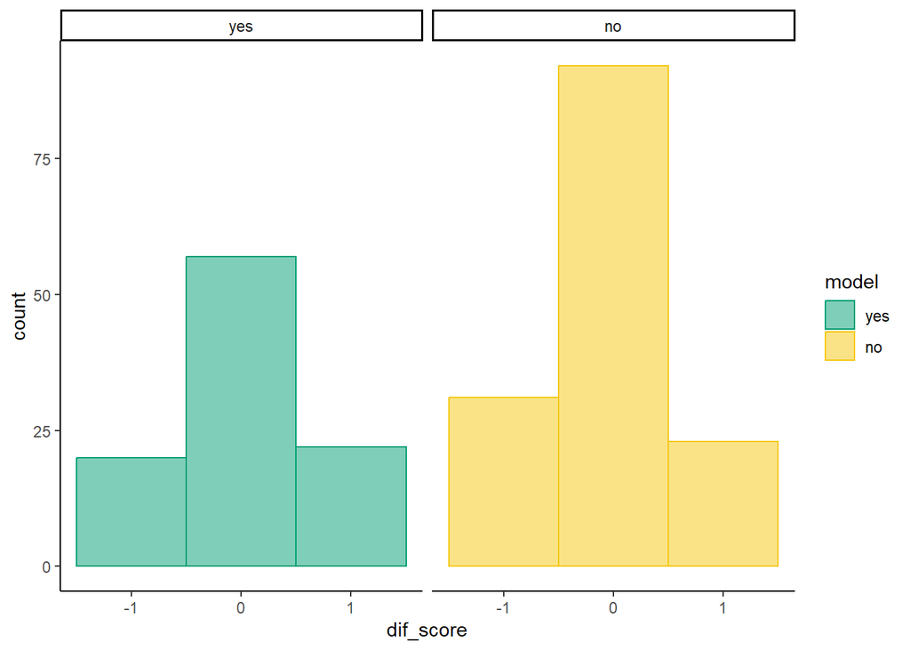

```r
ggplot(sum_s5, aes(x=dif_score ))+
  geom_histogram(binwidth=1, aes(color=model, fill = model), alpha = 0.5, position = "identity")+
  facet_grid(. ~ model)+
  scale_fill_manual(values = c("#009E73", "#F5C710"))+
  scale_color_manual(values = c("#009E73", "#F5C710"))+
  theme_classic()
```

Skill 6 - Read and interpret graphical representations of data: 3, 7, 8, 19

```r
# keep only the questions I need and only the checked row for each students b/c that will have the score column so I don't need to score by hand.
pre_s6 <- pre_all[pre_all$`Q..` %in% c(3, 7, 8, 19) & pre_all$`Answer.Match` == "Checked", ]

# now group by random number and calculate the score for skill 6
sum_pre_s6 <- pre_s6 %>%
  group_by(Random_Number) %>%
  summarize(pre_score = sum(Score), Sctn_Code = unique(Sctn_Code), model = unique(model))
# add percentage column
sum_pre_s6$pre_perc <- sum_pre_s6$pre_score / 4

# now for post
post_s6 <- post_all[post_all$`Q..` %in% c(3, 7, 8, 19) & post_all$`Answer.Match` == "Checked", ]

# now group by random number and calculate the score for skill 6
sum_post_s6 <- post_s6 %>%
  group_by(Random_Number) %>%
  summarize(post_score = sum(Score), Sctn_Code = unique(Sctn_Code), model = unique(model))
# add percentage column
sum_post_s6$post_perc <- sum_post_s6$post_score / 4

# merge those together
sum_s6 <- merge(sum_pre_s6, sum_post_s6, by = c("Random_Number", "Sctn_Code", "model"))

# calculate the difference in points
sum_s6$dif_score <- sum_s6$post_score - sum_s6$pre_score

# quick check of what things look like by modelling and section
sum_s6 %>%
  group_by(Sctn_Code) %>%
  summarize(mean_pre = mean(pre_perc),
            mean_post = mean(post_perc),
            mean_dif = mean(dif_score))
```

```
## # A tibble: 4 × 4
##   Sctn_Code mean_pre mean_post mean_dif
##   <chr>        <dbl>     <dbl>    <dbl>
## 1 REC1         0.765     0.781   0.0615
## 2 REC2         0.746     0.746   0
## 3 REC3         0.775     0.772  -0.0123
## 4 REC4         0.784     0.757  -0.108
```

```r
# 1 small increase, 2 exactly the same, 3 small decrease, 4 big decrease
# by modelling
sum_s6 %>%
  group_by(model) %>%
  summarize(mean_pre = mean(pre_perc),
            mean_post = mean(post_perc),
            mean_dif = mean(dif_score))
```

```
## # A tibble: 2 × 4
##   model mean_pre mean_post mean_dif
##   <chr>    <dbl>     <dbl>    <dbl>
## 1 no       0.771     0.776   0.0205
## 2 yes      0.760     0.75   -0.0404
```

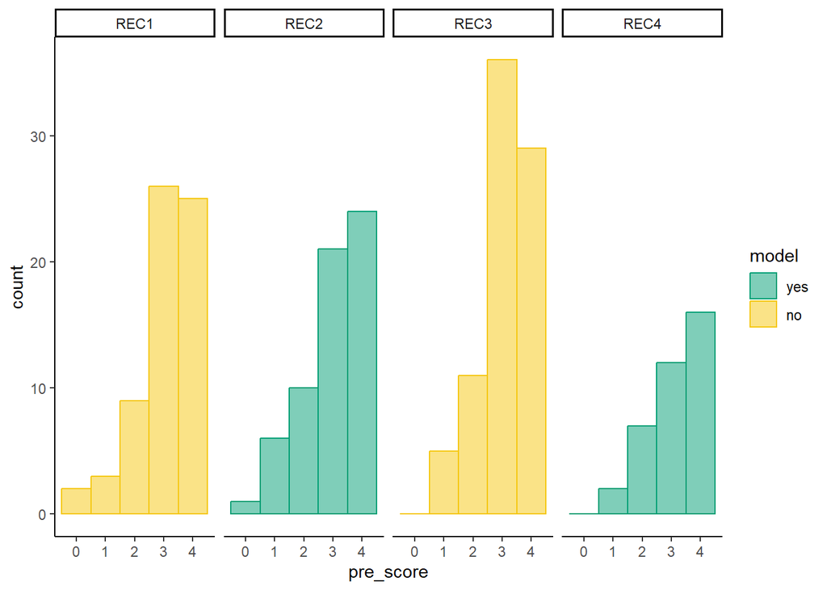

```r
# decrease but barely while no barely increased

# do t test to see if difference in scores pre/post matters by modelling
dif_s6 <- t.test(dif_score~model, data = sum_s6)

# add skill column
sum_s6$skill <- 6

#plots
sum_s6$model <- factor(sum_s6$model, levels = c("yes", "no"))

ggplot(sum_s6, aes(x=pre_score ))+
  geom_histogram(binwidth=1, aes(color=model, fill = model), alpha = 0.5, position = "identity")+
  facet_grid(. ~ Sctn_Code)+
  scale_fill_manual(values = c("#009E73", "#F5C710"))+
  scale_color_manual(values = c("#009E73", "#F5C710"))+
  theme_classic()
```

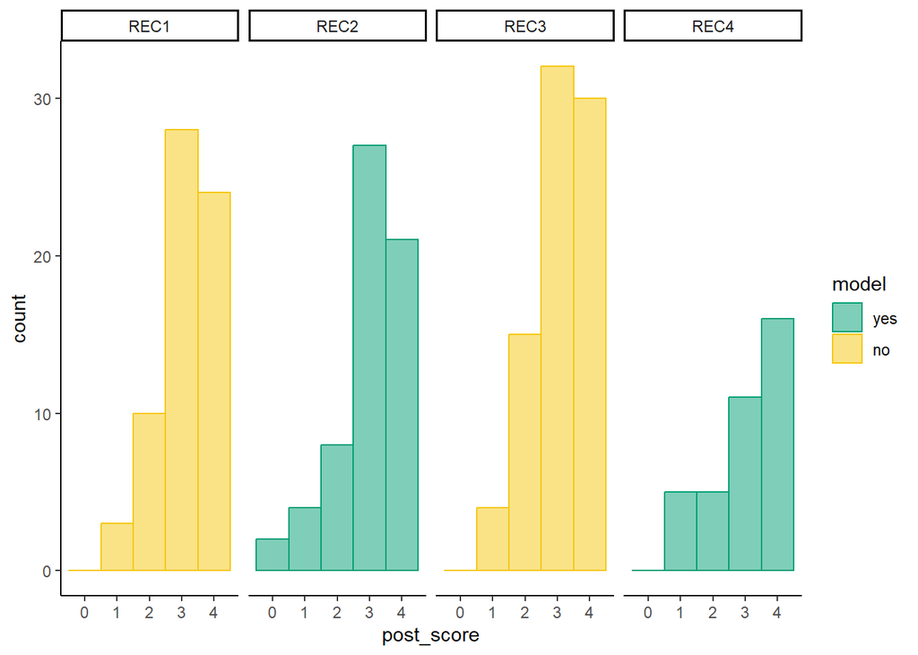

```r
ggplot(sum_s6, aes(x=post_score ))+
  geom_histogram(binwidth=1, aes(color=model, fill = model), alpha = 0.5, position = "identity")+
  facet_grid(. ~ Sctn_Code)+
  scale_fill_manual(values = c("#009E73", "#F5C710"))+
  scale_color_manual(values = c("#009E73", "#F5C710"))+
  theme_classic()
```

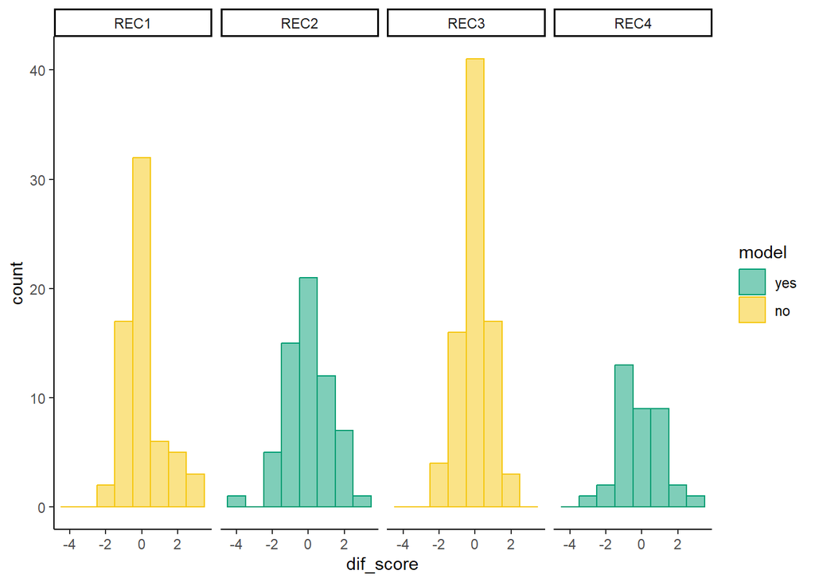

```r
ggplot(sum_s6, aes(x=dif_score ))+
  geom_histogram(binwidth=1, aes(color=model, fill = model), alpha = 0.5, position = "identity")+
  facet_grid(. ~ Sctn_Code)+
  scale_fill_manual(values = c("#009E73", "#F5C710"))+
  scale_color_manual(values = c("#009E73", "#F5C710"))+
  theme_classic()
```

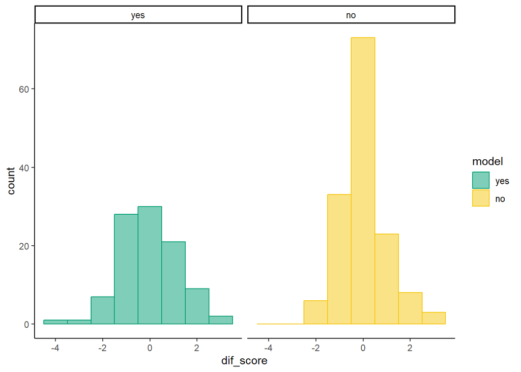

```r
ggplot(sum_s6, aes(x=dif_score ))+
  geom_histogram(binwidth=1, aes(color=model, fill = model), alpha = 0.5, position = "identity")+
  facet_grid(. ~ model)+
  scale_fill_manual(values = c("#009E73", "#F5C710"))+
  scale_color_manual(values = c("#009E73", "#F5C710"))+
  theme_classic()
```

Skill 7 - Solve problems using quantitative sklls, including probability and statistics: 17, 21, 24

```r
# keep only the questions I need and only the checked row for each students b/c that will have the score column so I don't need to score by hand.
pre_s7 <- pre_all[pre_all$`Q..` %in% c(17, 21, 24) & pre_all$`Answer.Match` == "Checked", ]

# now group by random number and calculate the score for skill 7
sum_pre_s7 <- pre_s7 %>%
  group_by(Random_Number) %>%
  summarize(pre_score = sum(Score), Sctn_Code = unique(Sctn_Code), model = unique(model))
# add percentage column
sum_pre_s7$pre_perc <- sum_pre_s7$pre_score / 3

# now for post
post_s7 <- post_all[post_all$`Q..` %in% c(17, 21, 24) & post_all$`Answer.Match` == "Checked", ]

# now group by random number and calculate the score for skill 7
sum_post_s7 <- post_s7 %>%
  group_by(Random_Number) %>%
  summarize(post_score = sum(Score), Sctn_Code = unique(Sctn_Code), model = unique(model))
# add percentage column
sum_post_s7$post_perc <- sum_post_s7$post_score / 3

# merge those together
sum_s7 <- merge(sum_pre_s7, sum_post_s7, by = c("Random_Number", "Sctn_Code", "model"))

# calculate the difference in points
sum_s7$dif_score <- sum_s7$post_score - sum_s7$pre_score

# quick check of what things look like by modelling and section
sum_s7 %>%
  group_by(Sctn_Code) %>%
  summarize(mean_pre = mean(pre_perc),
            mean_post = mean(post_perc),
            mean_dif = mean(dif_score))
```

```
## # A tibble: 4 × 4
##   Sctn_Code mean_pre mean_post mean_dif
##   <chr>        <dbl>     <dbl>    <dbl>
## 1 REC1         0.697     0.759   0.185
## 2 REC2         0.661     0.720   0.177
## 3 REC3         0.667     0.695   0.0864
## 4 REC4         0.721     0.757   0.108
```

```r
# 1+2 increased most
# by modelling
sum_s7 %>%
  group_by(model) %>%
  summarize(mean_pre = mean(pre_perc),
            mean_post = mean(post_perc),
            mean_dif = mean(dif_score))
```

```
## # A tibble: 2 × 4
##   model mean_pre mean_post mean_dif
##   <chr>    <dbl>     <dbl>    <dbl>
## 1 no       0.680     0.724    0.130
## 2 yes      0.684     0.734    0.152
```

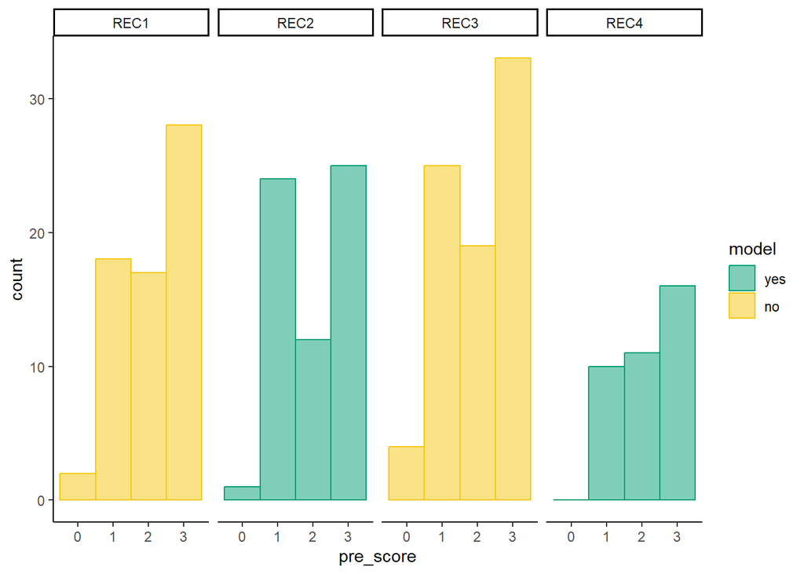

```r
# about the same increase

# do t test to see if difference in scores pre/post matters by modelling
dif_s7 <- t.test(dif_score~model, data = sum_s7)

# add skill column
sum_s7$skill <- 7

#plots
sum_s7$model <- factor(sum_s7$model, levels = c("yes", "no"))

ggplot(sum_s7, aes(x=pre_score ))+
  geom_histogram(binwidth=1, aes(color=model, fill = model), alpha = 0.5, position = "identity")+
  facet_grid(. ~ Sctn_Code)+
  scale_fill_manual(values = c("#009E73", "#F5C710"))+
  scale_color_manual(values = c("#009E73", "#F5C710"))+
  theme_classic()
```

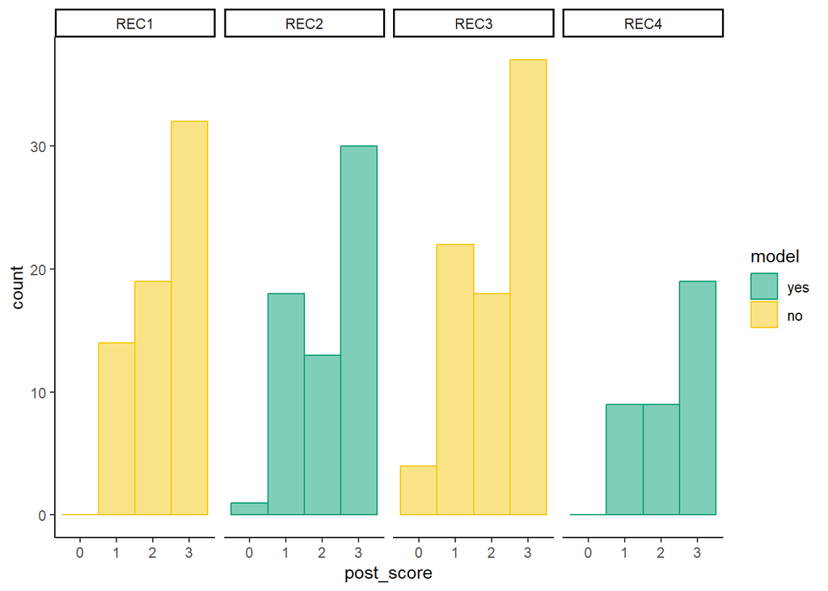

```r
ggplot(sum_s7, aes(x=post_score ))+
  geom_histogram(binwidth=1, aes(color=model, fill = model), alpha = 0.5, position = "identity")+
  facet_grid(. ~ Sctn_Code)+
  scale_fill_manual(values = c("#009E73", "#F5C710"))+
  scale_color_manual(values = c("#009E73", "#F5C710"))+
  theme_classic()
```

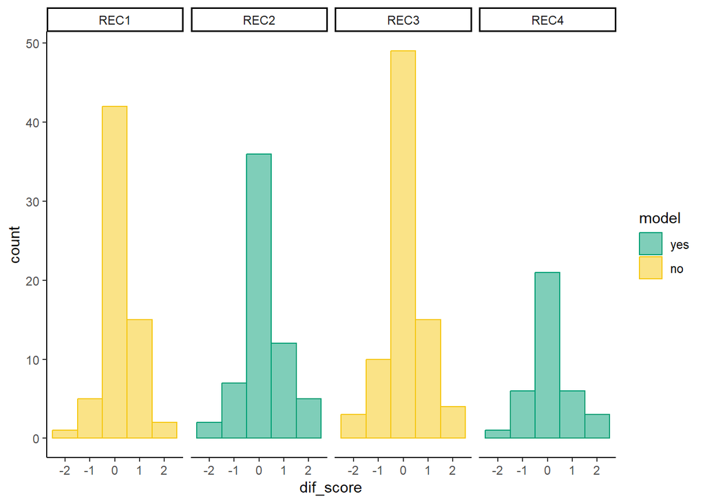

```r
ggplot(sum_s7, aes(x=dif_score ))+
  geom_histogram(binwidth=1, aes(color=model, fill = model), alpha = 0.5, position = "identity")+
  facet_grid(. ~ Sctn_Code)+
  scale_fill_manual(values = c("#009E73", "#F5C710"))+
  scale_color_manual(values = c("#009E73", "#F5C710"))+
  theme_classic()
```

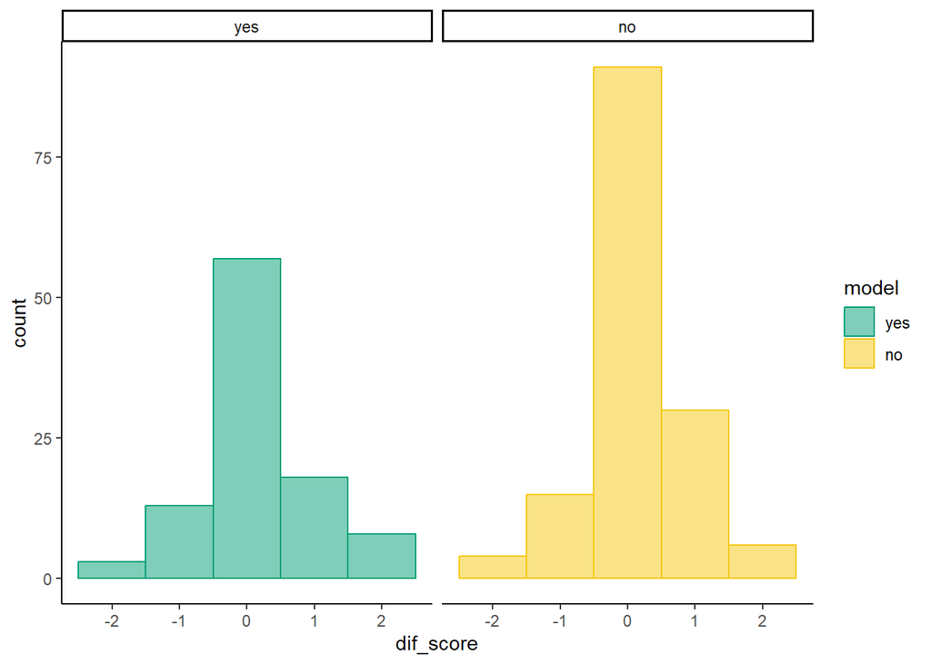

```r
ggplot(sum_s7, aes(x=dif_score ))+
  geom_histogram(binwidth=1, aes(color=model, fill = model), alpha = 0.5, position = "identity")+
  facet_grid(. ~ model)+
  scale_fill_manual(values = c("#009E73", "#F5C710"))+
  scale_color_manual(values = c("#009E73", "#F5C710"))+
  theme_classic()
```

Skill 8 - Understand and interpret basic statistics: 4, 20, 25

```r
# keep only the questions I need and only the checked row for each students b/c that will have the score column so I don't need to score by hand.
pre_s8 <- pre_all[pre_all$`Q..` %in% c(4, 20, 25) & pre_all$`Answer.Match` == "Checked", ]

# now group by random number and calculate the score for skill 8
sum_pre_s8 <- pre_s8 %>%
  group_by(Random_Number) %>%
  summarize(pre_score = sum(Score), Sctn_Code = unique(Sctn_Code), model = unique(model))
# add percentage column
sum_pre_s8$pre_perc <- sum_pre_s8$pre_score / 3

# now for post
post_s8 <- post_all[post_all$`Q..` %in% c(4, 20, 25) & post_all$`Answer.Match` == "Checked", ]

# now group by random number and calculate the score for skill 8
sum_post_s8 <- post_s8 %>%
  group_by(Random_Number) %>%
  summarize(post_score = sum(Score), Sctn_Code = unique(Sctn_Code), model = unique(model))
# add percentage column
sum_post_s8$post_perc <- sum_post_s8$post_score / 3

# merge those together
sum_s8 <- merge(sum_pre_s8, sum_post_s8, by = c("Random_Number", "Sctn_Code", "model"))

# calculate the difference in points
sum_s8$dif_score <- sum_s8$post_score - sum_s8$pre_score

# quick check of what things look like by modelling and section
sum_s8 %>%
  group_by(Sctn_Code) %>%
  summarize(mean_pre = mean(pre_perc),
            mean_post = mean(post_perc),
            mean_dif = mean(dif_score))
```

```
## # A tibble: 4 × 4
##   Sctn_Code mean_pre mean_post mean_dif
##   <chr>        <dbl>     <dbl>    <dbl>
## 1 REC1         0.615     0.677    0.185
## 2 REC2         0.602     0.602    0
## 3 REC3         0.617     0.654    0.111
## 4 REC4         0.622     0.658    0.108
```

```r
# 2 stayed exactly the same. rest increased with 1 increasing the most
# by modelling
sum_s8 %>%
  group_by(model) %>%
  summarize(mean_pre = mean(pre_perc),
            mean_post = mean(post_perc),
            mean_dif = mean(dif_score))
```

```
## # A tibble: 2 × 4
##   model mean_pre mean_post mean_dif
##   <chr>    <dbl>     <dbl>    <dbl>
## 1 no       0.616     0.664   0.144
## 2 yes      0.609     0.623   0.0404
```

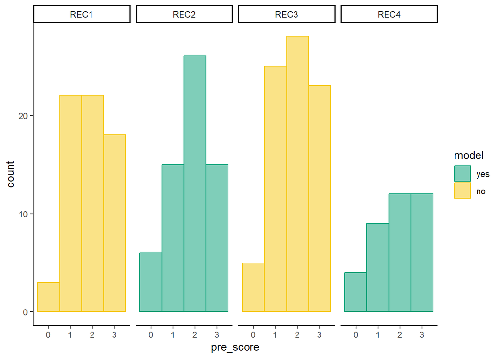

```r
# no increased much more than yes

# do t test to see if difference in scores pre/post matters by modelling
dif_s8 <- t.test(dif_score~model, data = sum_s8)

# add skill column
sum_s8$skill <- 8

#plots
sum_s8$model <- factor(sum_s8$model, levels = c("yes", "no"))

ggplot(sum_s8, aes(x=pre_score ))+
  geom_histogram(binwidth=1, aes(color=model, fill = model), alpha = 0.5, position = "identity")+
  facet_grid(. ~ Sctn_Code)+
  scale_fill_manual(values = c("#009E73", "#F5C710"))+
  scale_color_manual(values = c("#009E73", "#F5C710"))+
  theme_classic()
```

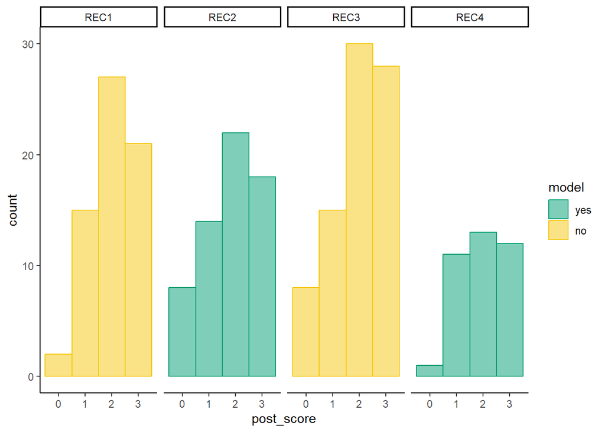

```r
ggplot(sum_s8, aes(x=post_score ))+
  geom_histogram(binwidth=1, aes(color=model, fill = model), alpha = 0.5, position = "identity")+
  facet_grid(. ~ Sctn_Code)+
  scale_fill_manual(values = c("#009E73", "#F5C710"))+
  scale_color_manual(values = c("#009E73", "#F5C710"))+
  theme_classic()
```

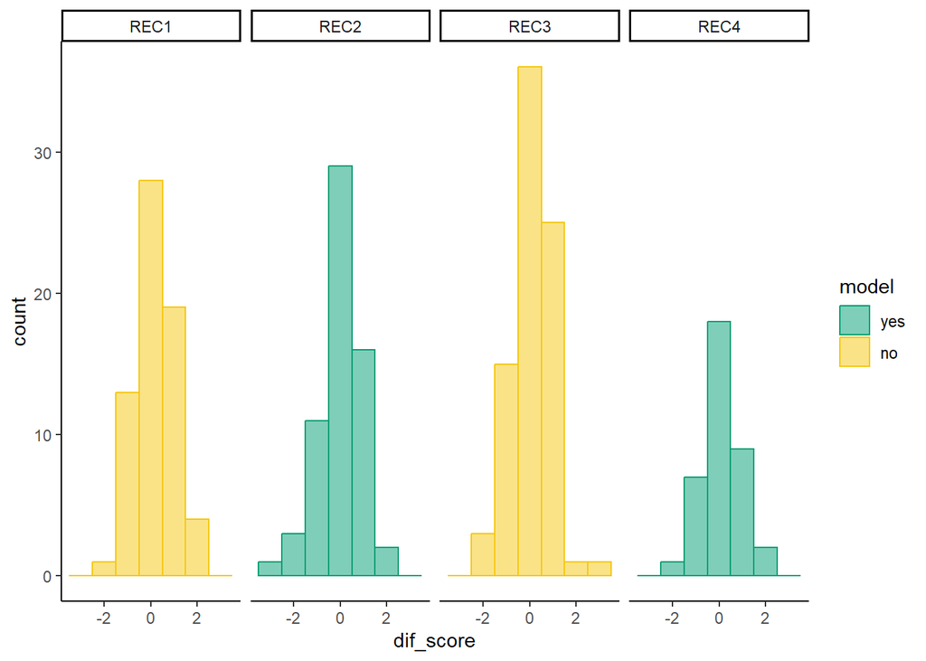

```r
ggplot(sum_s8, aes(x=dif_score ))+
  geom_histogram(binwidth=1, aes(color=model, fill = model), alpha = 0.5, position = "identity")+
  facet_grid(. ~ Sctn_Code)+
  scale_fill_manual(values = c("#009E73", "#F5C710"))+
  scale_color_manual(values = c("#009E73", "#F5C710"))+
  theme_classic()
```

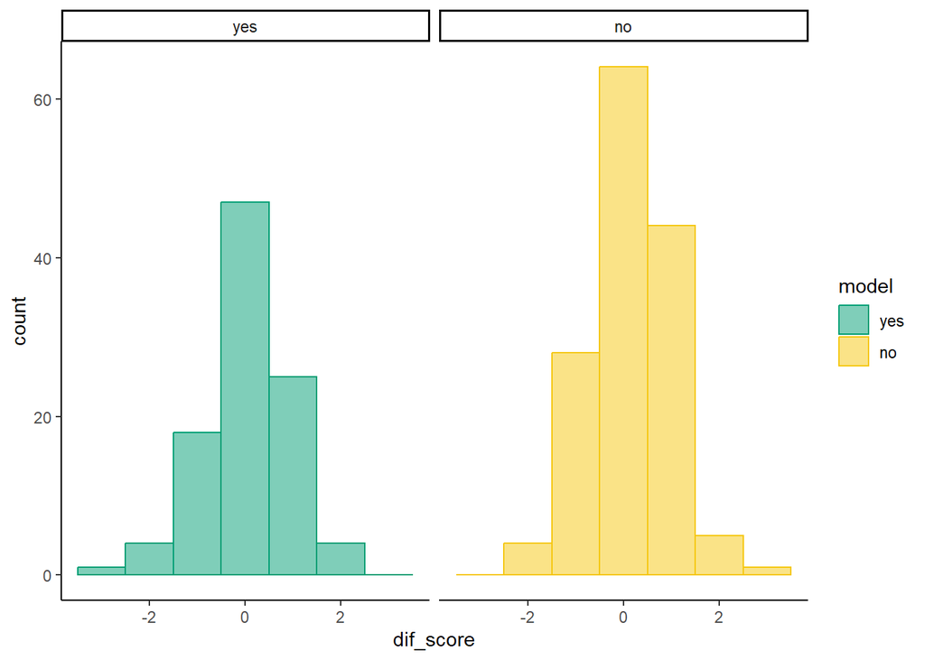

```r
ggplot(sum_s8, aes(x=dif_score ))+
  geom_histogram(binwidth=1, aes(color=model, fill = model), alpha = 0.5, position = "identity")+
  facet_grid(. ~ model)+
  scale_fill_manual(values = c("#009E73", "#F5C710"))+
  scale_color_manual(values = c("#009E73", "#F5C710"))+
  theme_classic()
```

Skill 9: Justify inferences, predictions, and conclusions based on quantitative data: 22, 29

```r
# keep only the questions I need and only the checked row for each students b/c that will have the score column so I don't need to score by hand.
pre_s9 <- pre_all[pre_all$`Q..` %in% c(22, 29) & pre_all$`Answer.Match` == "Checked", ]

# now group by random number and calculate the score for skill 9
sum_pre_s9 <- pre_s9 %>%
  group_by(Random_Number) %>%
  summarize(pre_score = sum(Score), Sctn_Code = unique(Sctn_Code), model = unique(model))
# add percentage column
sum_pre_s9$pre_perc <- sum_pre_s9$pre_score / 2

# now for post
post_s9 <- post_all[post_all$`Q..` %in% c(22, 29) & post_all$`Answer.Match` == "Checked", ]

# now group by random number and calculate the score for skill 9
sum_post_s9 <- post_s9 %>%
  group_by(Random_Number) %>%
  summarize(post_score = sum(Score), Sctn_Code = unique(Sctn_Code), model = unique(model))
# add percentage column
sum_post_s9$post_perc <- sum_post_s9$post_score / 2

# merge those together
sum_s9 <- merge(sum_pre_s9, sum_post_s9, by = c("Random_Number", "Sctn_Code", "model"))

# calculate the difference in points
sum_s9$dif_score <- sum_s9$post_score - sum_s9$pre_score

# quick check of what things look like by modelling and section
sum_s9 %>%
  group_by(Sctn_Code) %>%
  summarize(mean_pre = mean(pre_perc),
            mean_post = mean(post_perc),
            mean_dif = mean(dif_score))
```

```
## # A tibble: 4 × 4
##   Sctn_Code mean_pre mean_post mean_dif
##   <chr>        <dbl>     <dbl>    <dbl>
## 1 REC1         0.631     0.685   0.108
## 2 REC2         0.766     0.718  -0.0968
## 3 REC3         0.673     0.660  -0.0247
## 4 REC4         0.676     0.743   0.135
```

```r
# 1+4 decent increase, 2 decent decrase, 3 barely decrease
# by modelling
sum_s9 %>%
  group_by(model) %>%
  summarize(mean_pre = mean(pre_perc),
            mean_post = mean(post_perc),
            mean_dif = mean(dif_score))
```

```
## # A tibble: 2 × 4
##   model mean_pre mean_post mean_dif
##   <chr>    <dbl>     <dbl>    <dbl>
## 1 no       0.654     0.671   0.0342
## 2 yes      0.732     0.727  -0.0101
```

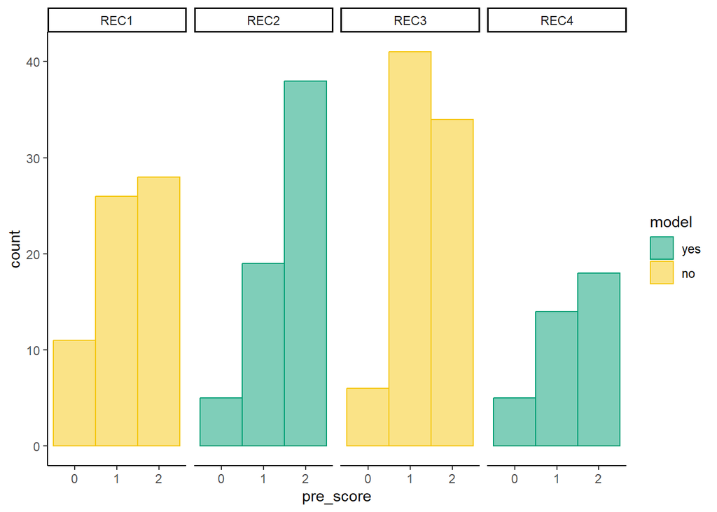

```r
# no barely increase, yes barely decrease

# do t test to see if difference in scores pre/post matters by modelling
dif_s9 <- t.test(dif_score~model, data = sum_s9)

# add skill column
sum_s9$skill <- 9

#plots
sum_s9$model <- factor(sum_s9$model, levels = c("yes", "no"))

ggplot(sum_s9, aes(x=pre_score ))+
  geom_histogram(binwidth=1, aes(color=model, fill = model), alpha = 0.5, position = "identity")+
  facet_grid(. ~ Sctn_Code)+
  scale_fill_manual(values = c("#009E73", "#F5C710"))+
  scale_color_manual(values = c("#009E73", "#F5C710"))+
  theme_classic()
```

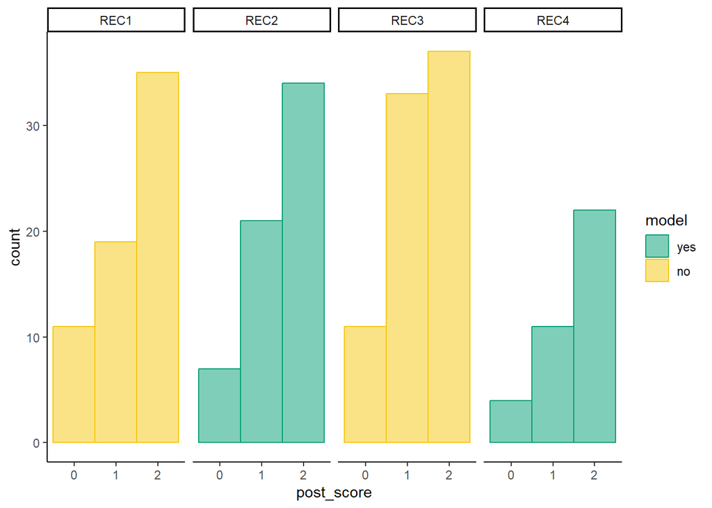

```r
ggplot(sum_s9, aes(x=post_score ))+
  geom_histogram(binwidth=1, aes(color=model, fill = model), alpha = 0.5, position = "identity")+
  facet_grid(. ~ Sctn_Code)+
  scale_fill_manual(values = c("#009E73", "#F5C710"))+
  scale_color_manual(values = c("#009E73", "#F5C710"))+
  theme_classic()
```

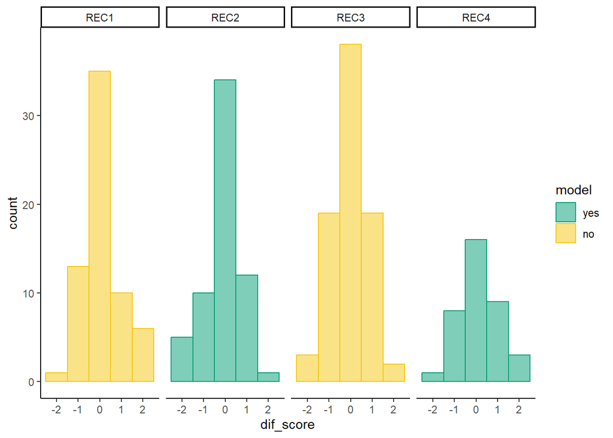

```r
ggplot(sum_s9, aes(x=dif_score ))+
  geom_histogram(binwidth=1, aes(color=model, fill = model), alpha = 0.5, position = "identity")+
  facet_grid(. ~ Sctn_Code)+
  scale_fill_manual(values = c("#009E73", "#F5C710"))+
  scale_color_manual(values = c("#009E73", "#F5C710"))+
  theme_classic()
```

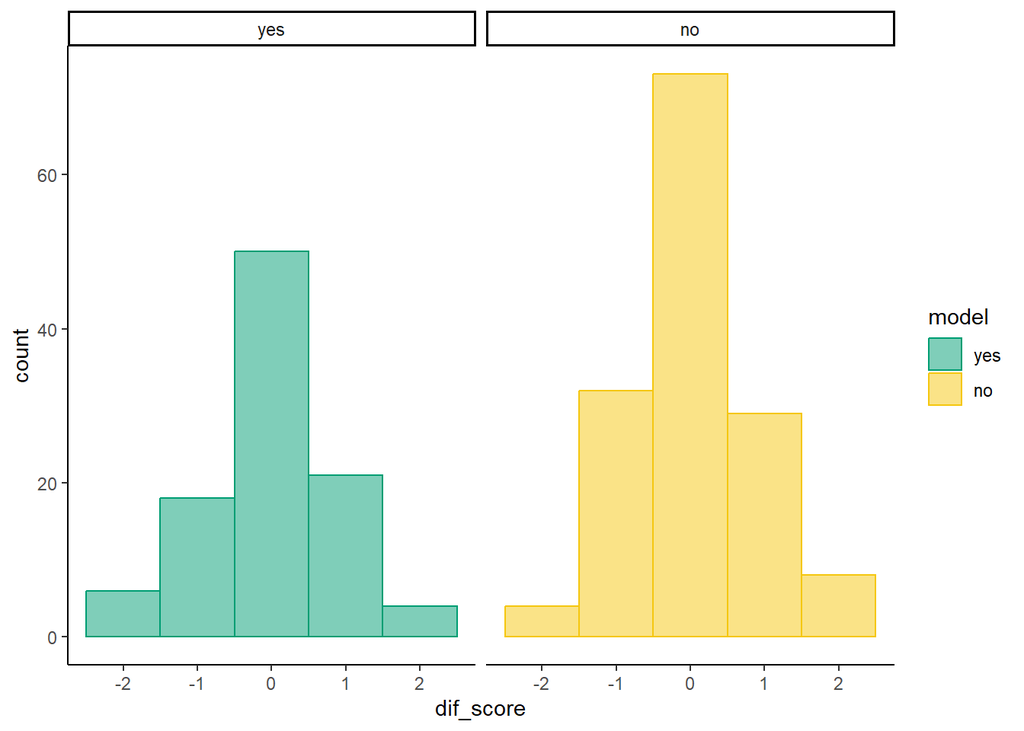

```r
ggplot(sum_s9, aes(x=dif_score ))+
  geom_histogram(binwidth=1, aes(color=model, fill = model), alpha = 0.5, position = "identity")+
  facet_grid(. ~ model)+
  scale_fill_manual(values = c("#009E73", "#F5C710"))+
  scale_color_manual(values = c("#009E73", "#F5C710"))+
  theme_classic()
```

## Plot!

Let’s make a fancy many facet boxplot :)

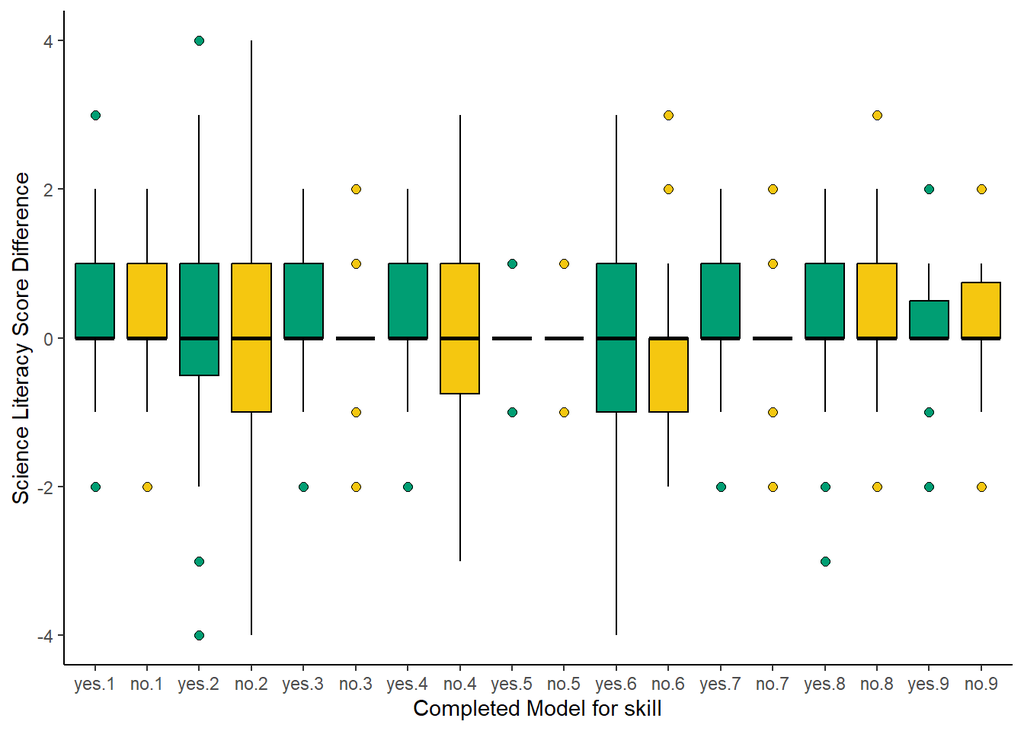

Just to see plots

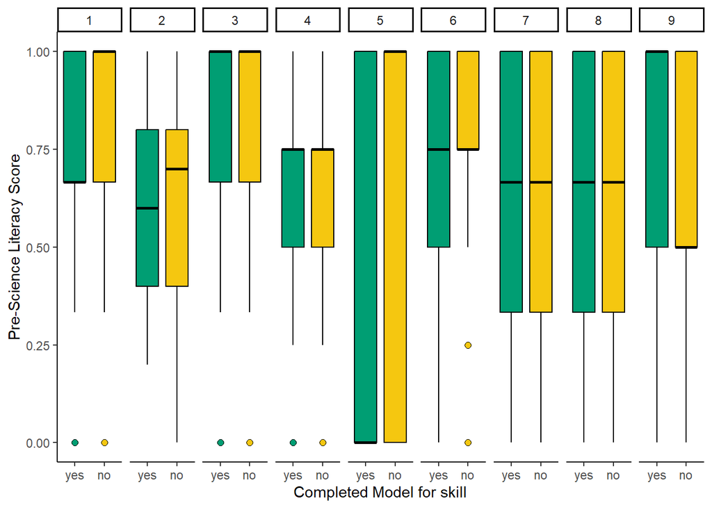

```r
# pre - don't expect a difference
ggplot(data = forplot, aes(x = model, y = pre_perc))+
  geom_boxplot(aes(fill = model), color = "black", outlier.color = "black", outlier.shape = 21, outlier.size = 2, notch = FALSE)+
  facet_grid(. ~ skill)+
  labs(x = "Completed Model for skill", y = "Pre-Science Literacy Score")+
  scale_fill_manual(values = c("#009E73", "#F5C710"))+
  scale_color_manual(values = c("#009E73", "#F5C710"))+
  theme_classic()+
  theme(legend.position = "none")
```

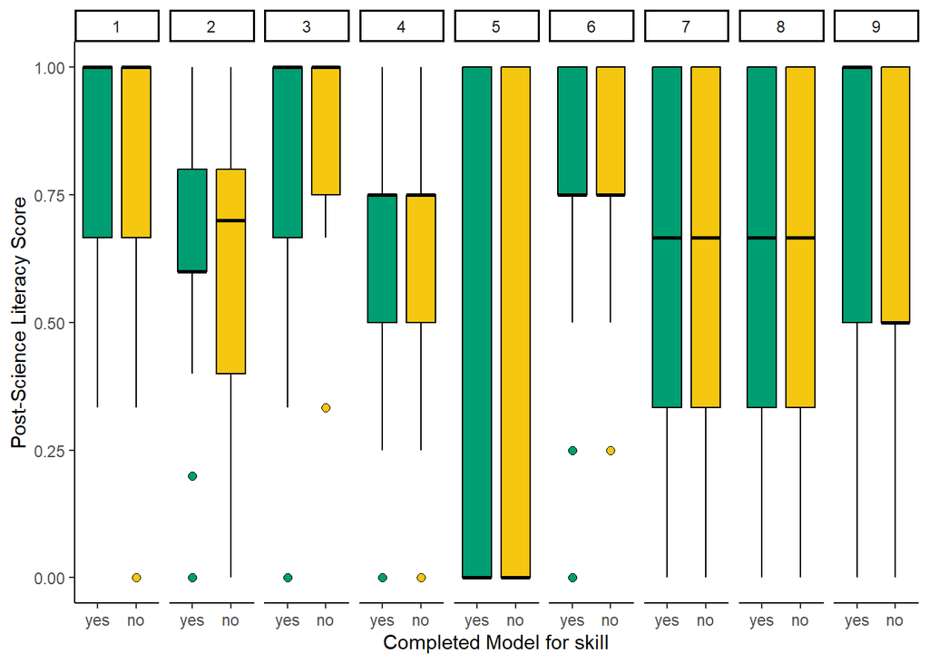

```r
ggplot(data = forplot, aes(x = model, y = post_perc))+
  geom_boxplot(aes(fill = model), color = "black", outlier.color = "black", outlier.shape = 21, outlier.size = 2, notch = FALSE)+
  facet_grid(. ~ skill)+
  labs(x = "Completed Model for skill", y = "Post-Science Literacy Score")+
  scale_fill_manual(values = c("#009E73", "#F5C710"))+
  scale_color_manual(values = c("#009E73", "#F5C710"))+
  theme_classic()+
  theme(legend.position = "none")
```

```r
#print all the p values to see if anything is significant anywhere (I don't think it is)
dif_s1$p.value
```

```
## [1] 0.9918032
```

```r
dif_s2$p.value # lowest p value! 0.18 would not have guessed from the graph.
```

```
## [1] 0.1834997
```

```r
dif_s3$p.value
```

```
## [1] 0.4359397
```

```r
dif_s4$p.value
```

```
## [1] 0.2979023
```

```r
dif_s5$p.value
```

```
## [1] 0.3661232
```

```r
dif_s6$p.value
```

```
## [1] 0.6858128
```

```r
dif_s7$p.value
```

```
## [1] 0.841479
```

```r
dif_s8$p.value
```

```
## [1] 0.3834881
```

```r
dif_s9$p.value
```

```
## [1] 0.7007849
```

# Does post science literacy score predict final presentation score?

```
## Linear mixed model fit by REML. t-tests use Satterthwaite's method [
## lmerModLmerTest]
## Formula: pres_perc ~ post_perc * model + (1 | model:Sctn_Code)
##    Data: All_summary
##
## REML criterion at convergence: -305.6
##
## Scaled residuals:
##     Min      1Q  Median      3Q     Max
## -6.9691 -0.3126  0.1927  0.5623  1.3551
##
## Random effects:
##  Groups          Name        Variance Std.Dev.
##  model:Sctn_Code (Intercept) 0.001143 0.03381
##  Residual                    0.015507 0.12453
## Number of obs: 245, groups:  model:Sctn_Code, 4
##
## Fixed effects:
##                    Estimate Std. Error        df t value Pr(>|t|)
## (Intercept)         0.79968    0.07210  76.40340  11.091   <2e-16 ***
## post_perc           0.09468    0.09219 238.84671   1.027    0.305
## modelno             0.07487    0.09300  57.52563   0.805    0.424
## post_perc:modelno  -0.09128    0.11705 238.98596  -0.780    0.436
## ---
## Signif. codes:  0 '***' 0.001 '**' 0.01 '*' 0.05 '.' 0.1 ' ' 1
##
## Correlation of Fixed Effects:
##             (Intr) pst_pr modeln
## post_perc   -0.926
## modelno     -0.775  0.718
## pst_prc:mdl  0.730 -0.788 -0.915
```

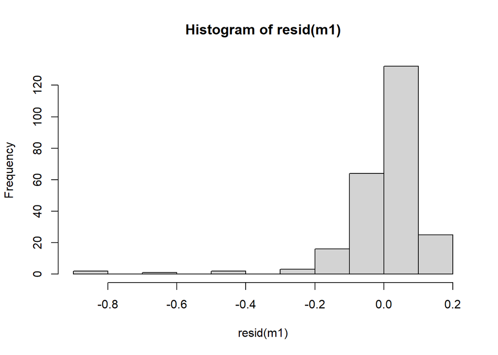

```
##
## Call:
## lm(formula = pres_perc ~ post_perc, data = All_summary)
##
## Residuals:
##      Min       1Q   Median       3Q      Max
## -0.87247 -0.04102  0.02878  0.07315  0.13210
##
## Coefficients:
##             Estimate Std. Error t value Pr(>|t|)
## (Intercept)  0.84625    0.04253   19.90   <2e-16 ***
## post_perc    0.04080    0.05743    0.71    0.478
## ---
## Signif. codes:  0 '***' 0.001 '**' 0.01 '*' 0.05 '.' 0.1 ' ' 1
##
## Residual standard error: 0.126 on 243 degrees of freedom
## Multiple R-squared:  0.002073,   Adjusted R-squared:  -0.002034
## F-statistic: 0.5048 on 1 and 243 DF,  p-value: 0.4781
```

Need to calculate and use group mean science literacy score so I do not have psuedoreplication within my study.

```r
group_means <- All_summary %>%
  group_by(LabTeams) %>% group_by(model, .add = TRUE) %>% group_by(Sctn_Code, .add = TRUE) %>%
  summarize(pres_perc = mean(pres_perc), pre_perc = mean(pre_perc), post_perc = mean(post_perc), dif_perc = mean(dif_perc), n = n())
m2 <- lmer(pres_perc ~ post_perc*model + (1|model:Sctn_Code), data = group_means)
summary(m2)
```

```
## Linear mixed model fit by REML. t-tests use Satterthwaite's method [
## lmerModLmerTest]
## Formula: pres_perc ~ post_perc * model + (1 | model:Sctn_Code)
##    Data: group_means
##
## REML criterion at convergence: -181.4
##
## Scaled residuals:
##     Min      1Q  Median      3Q     Max
## -6.6947 -0.4045  0.2165  0.6050  1.6062
##
## Random effects:
##  Groups          Name        Variance Std.Dev.
##  model:Sctn_Code (Intercept) 0.001802 0.04245
##  Residual                    0.014473 0.12030
## Number of obs: 142, groups:  model:Sctn_Code, 4
##
## Fixed effects:
##                   Estimate Std. Error       df t value Pr(>|t|)
## (Intercept)         0.6861     0.1043  85.9774   6.577 3.58e-09 ***
## post_perc           0.2417     0.1367 135.9857   1.768   0.0793 .
## modelno             0.2440     0.1404  78.3765   1.738   0.0862 .
## post_perc:modelno  -0.3174     0.1827 136.1120  -1.737   0.0847 .
## ---
## Signif. codes:  0 '***' 0.001 '**' 0.01 '*' 0.05 '.' 0.1 ' ' 1
##
## Correlation of Fixed Effects:
##             (Intr) pst_pr modeln
## post_perc   -0.945
## modelno     -0.743  0.702
## pst_prc:mdl  0.707 -0.748 -0.942
```

```r
# model without random effect to simplify plotting. the actual model would have two "model yes' lines and two "model no" lines because 2 sections are in each treatment
m2.2 <- lm(pres_perc ~ post_perc*model, data = group_means)
summary(m2.2)
```

```
##
## Call:
## lm(formula = pres_perc ~ post_perc * model, data = group_means)
##
## Residuals:
##      Min       1Q   Median       3Q      Max
## -0.85122 -0.04386  0.02610  0.07569  0.16955
##
## Coefficients:
##                   Estimate Std. Error t value Pr(>|t|)
## (Intercept)         0.7044     0.1023   6.889 1.82e-10 ***
## post_perc           0.2283     0.1402   1.629    0.106
## modelno             0.2165     0.1369   1.582    0.116
## post_perc:modelno  -0.2938     0.1872  -1.570    0.119
## ---
## Signif. codes:  0 '***' 0.001 '**' 0.01 '*' 0.05 '.' 0.1 ' ' 1
##
## Residual standard error: 0.1235 on 138 degrees of freedom
## Multiple R-squared:  0.02113,    Adjusted R-squared:  -0.0001507
## F-statistic: 0.9929 on 3 and 138 DF,  p-value: 0.3982
```

```r
m3 <- lmer(pres_perc ~ dif_perc*model + (1|model:Sctn_Code), data = group_means)
summary(m3)
```

```
## Linear mixed model fit by REML. t-tests use Satterthwaite's method [
## lmerModLmerTest]
## Formula: pres_perc ~ dif_perc * model + (1 | model:Sctn_Code)
##    Data: group_means
##
## REML criterion at convergence: -181.4
##
## Scaled residuals:
##     Min      1Q  Median      3Q     Max
## -6.3362 -0.4021  0.2115  0.5881  1.8556
##
## Random effects:
##  Groups          Name        Variance Std.Dev.
##  model:Sctn_Code (Intercept) 0.001359 0.03687
##  Residual                    0.014540 0.12058
## Number of obs: 142, groups:  model:Sctn_Code, 4
##
## Fixed effects:
##                   Estimate Std. Error        df t value Pr(>|t|)
## (Intercept)        0.85599    0.03084   2.03183  27.756  0.00119 **
## dif_perc           0.21779    0.13459 137.29226   1.618  0.10792
## modelno            0.02083    0.04256   1.84658   0.489  0.67649
## dif_perc:modelno  -0.33290    0.19169 136.89787  -1.737  0.08470 .
## ---
## Signif. codes:  0 '***' 0.001 '**' 0.01 '*' 0.05 '.' 0.1 ' ' 1
##
## Correlation of Fixed Effects:
##             (Intr) df_prc modeln
## dif_perc    -0.100
## modelno     -0.725  0.073
## df_prc:mdln  0.071 -0.702 -0.087
```

```r
# model without random effect to simplify plotting. the actual model would have two "model yes' lines and two "model no" lines because 2 sections are in each treatment
m3.2 <- lm(pres_perc ~ dif_perc*model, data = group_means)
summary(m3.2)
```

```
##
## Call:
## lm(formula = pres_perc ~ dif_perc * model, data = group_means)
##
## Residuals:
##      Min       1Q   Median       3Q      Max
## -0.78945 -0.04404  0.02320  0.07504  0.19964
##
## Coefficients:
##                  Estimate Std. Error t value Pr(>|t|)
## (Intercept)       0.86220    0.01654  52.137   <2e-16 ***
## dif_perc          0.25462    0.13612   1.871   0.0635 .
## modelno           0.01275    0.02139   0.596   0.5519
## dif_perc:modelno -0.35764    0.19430  -1.841   0.0678 .
## ---
## Signif. codes:  0 '***' 0.001 '**' 0.01 '*' 0.05 '.' 0.1 ' ' 1
##
## Residual standard error: 0.123 on 138 degrees of freedom
## Multiple R-squared:  0.02884,    Adjusted R-squared:  0.007732
## F-statistic: 1.366 on 3 and 138 DF,  p-value: 0.2557
```

When predicting final presentation score, the post survey score, the modelling activity, and the interaction are all below p=0.1 with t values at about 1.7.